# HW-22088

## Question

1. Exercises 2 (page 204, Advanced R)
2. Exercises 1 (page 213, Advanced R)
3. Rcpp Exercise

## Answer

### Exercises 2 (page 204, Advanced R)

**problem**

in book

**Solution.**

First, we use ‘lapply()’ to apply ‘scale01’ to every column of a data frame ‘cars’ in R.

```r
rm(list=ls())
scale01<-function(x){
  rng<-range(x,na.rm = TRUE)
  (x-rng[1])/(rng[2]-rng[1])
}
scale_cars<-data.frame(lapply(cars, scale01))
head(scale_cars)
```

```
##       speed       dist
## 1 0.0000000 0.00000000
## 2 0.0000000 0.06779661
## 3 0.1428571 0.01694915
## 4 0.1428571 0.16949153
## 5 0.1904762 0.11864407
## 6 0.2380952 0.06779661
```

However, there will be an error if the data frame has a non-numeric column because ‘range()’ is not meaningful for factors. In order to apply ‘scale01’ to every numeric column in a data frame, we use:

```r
#new_scale01<-function(x){
#  if(is.numeric(x)==T){
#    scale01(x)
#  }
#  else{
#    x
#  }
#}
#scale_iris<-data.frame(lapply(iris, new_scale01))
scale_iris<-data.frame(lapply(iris, function(x) if (is.numeric(x)) scale01(x) else x))
head(scale_iris)
```

```
##   Sepal.Length Sepal.Width Petal.Length Petal.Width Species
## 1   0.22222222   0.6250000   0.06779661  0.04166667  setosa
## 2   0.16666667   0.4166667   0.06779661  0.04166667  setosa
## 3   0.11111111   0.5000000   0.05084746  0.04166667  setosa
## 4   0.08333333   0.4583333   0.08474576  0.04166667  setosa
## 5   0.19444444   0.6666667   0.06779661  0.04166667  setosa
## 6   0.30555556   0.7916667   0.11864407  0.12500000  setosa
```

### Exercises 1 (page 213, Advanced R)

**problem**

in book

**Solution**

```r
## numeric data frame
vapply(cars,sd,numeric(1))
```

```
##     speed      dist
##  5.287644 25.769377
```

```r
## mixed data frame
#index<-vapply(iris, is.numeric, logical(1))
#vapply(iris[index],sd,numeric(1))
vapply(iris[vapply(iris, is.numeric, logical(1))],sd,numeric(1))
```

```
## Sepal.Length  Sepal.Width Petal.Length  Petal.Width
##    0.8280661    0.4358663    1.7652982    0.7622377
```

### Rcpp Exercise

**problem**

Gibbs in R and C

**Solution.**

```r
library(Rcpp)
library(StatComp22088)
library(microbenchmark)
## Functions by R and C++
#cppFunction('NumericMatrix gibbsC(double mu1,double sigma1,double mu2,double sigma2,double rho,int N) {
#  NumericMatrix Z(N, 2);
#  double s1=0,s2=0;
#  s1 = sqrt(1-rho*rho)*sigma1;
#  s2 = sqrt(1-rho*rho)*sigma2;
#  Z(0,0) = 0;
#  Z(0,1) = 0;
#  double y = 0, m1 = 0, x=0, m2=0;
#  for(int i = 1; i < N; i++) {
#    y = Z(i-1, 1);
#    m1 = mu1 + rho * (y - mu2) * sigma1/sigma2;
#    Z(i, 0) = rnorm(1, m1, s1)[0];
#    x = Z(i, 0);
#    m2 = mu2 + rho * (x - mu1) * sigma2/sigma1;
#    Z(i, 1) = rnorm(1, m2, s2)[0];
#  }
#  return(Z);
#}')
gibbsR <- function(mu,sigma,rho,N){
  Z <- matrix(0, N, 2) #the chain, a bivariate sample
  s1 <- sqrt(1-rho^2)*sigma[1]
  s2 <- sqrt(1-rho^2)*sigma[2]
  Z[1, ] <- c(0,0)
  for (i in 2:N) {
    y <- Z[i-1, 2]
    m1 <- mu[1] + rho * (y - mu[2]) * sigma[1]/sigma[2]
    Z[i, 1] <- rnorm(1, m1, s1)
    x <- Z[i, 1]
    m2 <- mu[2] + rho * (x - mu[1]) * sigma[2]/sigma[1]
    Z[i, 2] <- rnorm(1, m2, s2)
  }
  return(Z)
}
```

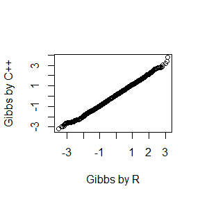

```r
set.seed(22088)
N <- 5000 #length of chain
burn <- 1000 #burn-in length
rho <- 0.9 #correlation
mu<-c(0,0) #mean
sigma<-c(1,1) #unit standard deviations
## Gibbs by R
Z<-gibbsR(mu,sigma,rho,N)
b <- burn + 1
dtR <- Z[b:N, ]
## Gibbs by C++
Z<-gibbsC(mu[1],sigma[1],mu[2],sigma[2],rho,N)
b <- burn + 1
dtC <- Z[b:N, ]
## QQ-plot
qqplot(dtR[,1],dtC[,1],xlab = "Gibbs by R",ylab = "Gibbs by C++")
```

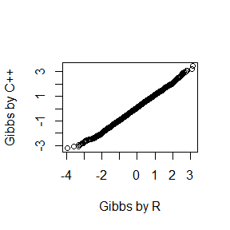

```r
qqplot(dtR[,2],dtC[,2],xlab = "Gibbs by R",ylab = "Gibbs by C++")
```

```r
## computation time
ts <- microbenchmark(gibbsR=gibbsR(mu,sigma,rho,N),gibbsC=gibbsC(mu[1],sigma[1],mu[2],sigma[2],rho,N))
summary(ts)[,c(1,3,5,6)]
```

```
##     expr        lq    median        uq
## 1 gibbsR 25.201951 29.675051 32.044802
## 2 gibbsC  2.416551  2.502201  3.079152
```

```r
rm(list=ls())
```